# Lab 4: Avocado Prices and Cost of Living in California

- Show All Code
- Hide All Code
- View Source

Author

Rachel Friesen

## Question 1

*The data set is from the Hass Avocado Board and downloaded from kaggle.com. It contains the prices and volume of retail sales of avocados from 2015 - 2018 in various cities and regions across the United States. Variables included are date, year, average price of single avocados, type (conventional or organic), region, total volume, and lastly the total number of avocados with three different Product Lookup (PLU) codes, which corresponds to avocado size. There are 18249 observations of 14 variables.*

## Question 2

Clean the data

```r
# load libraries
library(tidyverse)
library(here)

# read in data
avocado <- read_csv(here('labs', 'lab_4', 'avocado.csv'))

# clean data
avocado_clean <- avocado %>%
  rename(small = "4046",
         large = "4225",
         extra_large = "4770",
         total_volume = "Total Volume")

# examine list of unique region names
#unique(avocado$region)

# create data frame with all regions
regions_all <- data.frame(region =
                       c("West", "Midsouth", "Northeast", "SouthCentral",
                         "WestTexNewMexico","California", "NorthernNewEngland",
                         "Southeast", "GreatLakes","Plains", "TotalUS",
                         "SouthCarolina"))

# create data frame with major regions
regions_major <- data.frame(region =
                       c("West", "Midsouth", "Northeast", "SouthCentral",
                         "Southeast", "GreatLakes", "Plains"))

# create data frame with just metro area regions
regions_metro <- avocado_clean %>%
  anti_join(y = regions_all, by = "region") %>%
  select(region) %>%
  unique()
```

## Question 3

Which major region sold the most organic, small Hass avocados in 2017?

*West*

*REVISION COMMENT:*

*I neglected to sum up all the small avocado sales for each region for the entire year. Instead, I was answering the following question: which major region sold the most organic, small Hass avocados in any given week in 2017? This question is very different than the one asked. In the future, I’ll try to be more careful and think through the nuances of both what the question is asking and how the data is structured. (i.e. the avocado data is weekly sales data). When I corrected my code, I came up with a different answer (West instead of Northeast).*

```r
avocado_clean %>%
  semi_join(y = regions_major, by = "region")  %>%
  filter(year == 2017,  type == "organic") %>%
  group_by(region) %>%
  summarize(small_sum = sum(small)) %>%
  slice_max(order_by = small_sum, n = 1) %>%
  pull(region)
```

```
[1] "West"
```

## Question 4

Use the `separate()` function to split the `Date` variable into year, month, and day. In which month is the highest volume of avocado sales?

*February has the highest volume of avocado sales.*

```r
avocado_clean %>%
  separate(col = "Date", sep = "-", into = c("year", "month", "date")) %>%
  group_by(month) %>%
  summarise(mean = mean(`total_volume`)) %>%
  slice_max(order_by = mean)
```

```
# A tibble: 1 × 2
  month     mean
  <chr>    <dbl>
1 02    1018825.
```

## Question 5

Which metro area regions sold the most total avocados? Plot side-by-side boxplots of total volume for only the five regions with the highest averages for the `Total Volume` variable.

*Dallas-Fort Worth, Houston, Los Angeles, New York, Phoenix-Tucson*

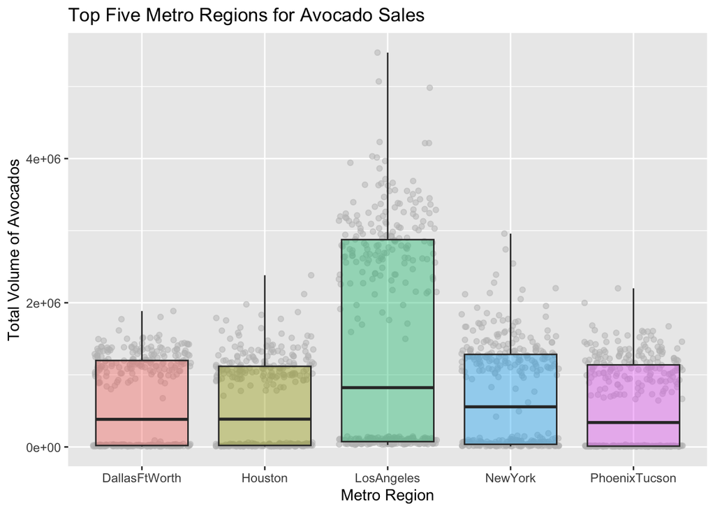

```r
# find the top 5 metro regions for total avocado sales
regions_Q5 <- avocado_clean %>%
  semi_join(y = regions_metro, by = "region")  %>%
  group_by(region) %>%
  summarize(mean = mean(total_volume)) %>%
  slice_max(order_by = mean, n = 5) %>%
  select(region)

# filter data to only include the top 5 metro areas
avocado_clean_Q5 <- avocado_clean %>%
  semi_join(y = regions_Q5, by = "region")

# create plot with filtered data
ggplot(data = avocado_clean_Q5,
       aes(x = region, y = total_volume, fill = region)) +
  geom_jitter(color = "gray", alpha = .5) +
  geom_boxplot(alpha = .4) +
  theme(legend.position = "none") +
  labs(title = "Top Five Metro Regions for Avocado Sales",
       x = "Metro Region",
       y = "Total Volume of Avocados")
```

## Question 6

In which California region is the price of organic versus conventional avocados most different? Support your answer with a few summary statistics and a visualization.

*San Francisco has the largest price difference between organic and conventional avocados. The average price difference is* $0.81. *The median price difference is $0.91.*

```r
# create data frame with four California metro areas
regions_Q6 <- data.frame(region =
                       c("LosAngeles", "SanDiego", "Sacramento", "SanFrancisco"))

# make data frame with clean avocado data with only the Californai metro areas
avocado_clean_Q6 <- avocado_clean %>%
  semi_join(y = regions_Q6, by = "region")

# find the median price difference
avocado_clean_Q6 %>%
  group_by(region, type) %>%
  summarize(MedPrice = median(AveragePrice))  %>%
  pivot_wider(names_from = type, values_from = MedPrice) %>%
  mutate(med_difference = organic - conventional) %>%
  ungroup() %>%
  slice_max(order_by = med_difference, n = 1)
```

```
# A tibble: 1 × 4
  region       conventional organic med_difference
  <chr>               <dbl>   <dbl>          <dbl>
1 SanFrancisco         1.38    2.29           0.91
```

```r
# find the average price difference
avocado_clean_Q6 %>%
  group_by(region, type) %>%
  summarize(AveragePrice = mean(AveragePrice))  %>%
  pivot_wider(names_from = type, values_from = AveragePrice) %>%
  mutate(avg_difference = organic - conventional) %>%
  ungroup() %>%
  slice_max(order_by = avg_difference, n = 1)
```

```
# A tibble: 1 × 4
  region       conventional organic avg_difference
  <chr>               <dbl>   <dbl>          <dbl>
1 SanFrancisco         1.40    2.21          0.814
```

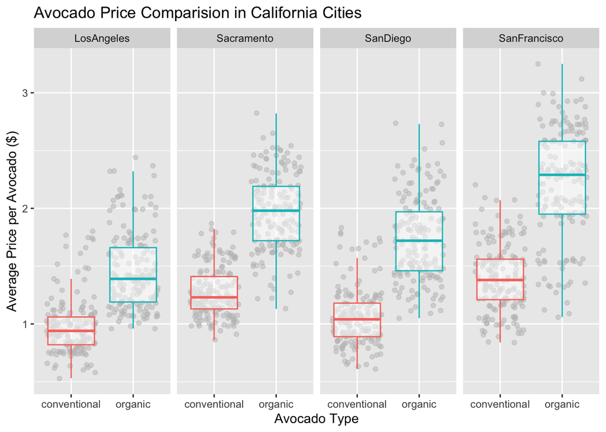

```r
# plot the data
ggplot(data = avocado_clean_Q6,
       mapping = aes(x = type,
                     y = AveragePrice,
                     color = type)) +
  geom_jitter(color = "gray", alpha = .5) +
  geom_boxplot(outlier.shape = NA, alpha = .5) +
  facet_grid(~ region) +
  theme(legend.position = "none") +
  labs(title = "Avocado Price Comparision in California Cities",
       x = "Avocado Type",
       y = "Average Price per Avocado ($)")
```

## Question 7

The following plot shows, for all four California regions, the proportion of the mean Hass avocado sales that are small, large, or extra large; conventional vs. organic. Recreate the plot.

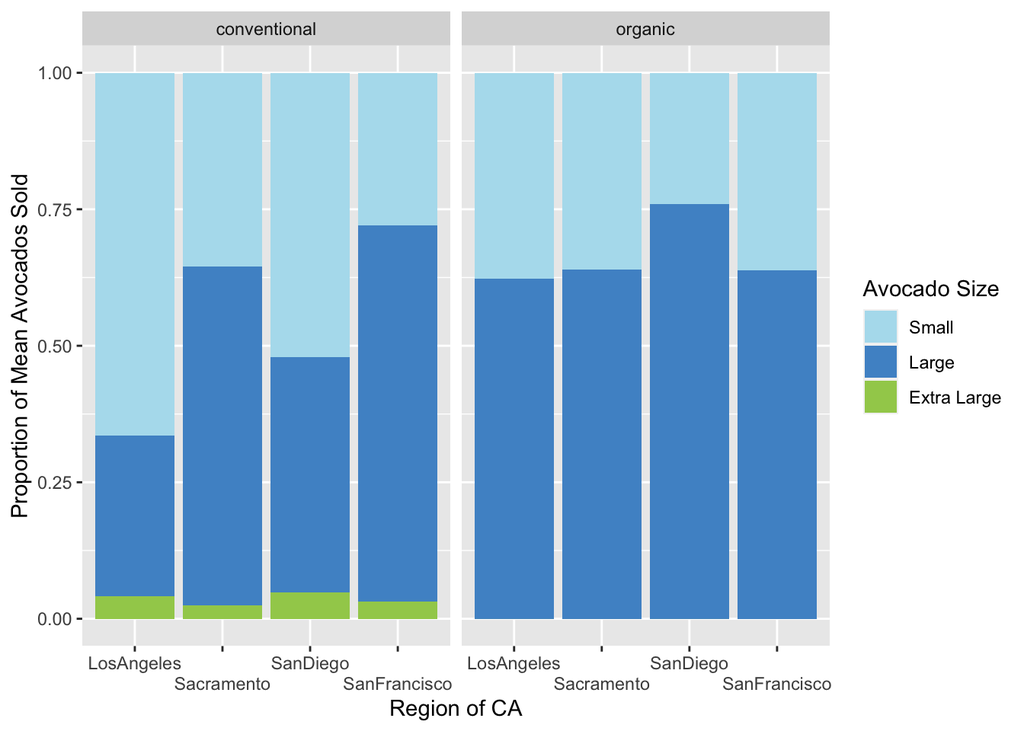

```r
# restructure the data and calculate mean sales per category
avocado_clean_Q7 <- avocado_clean_Q6 %>%
  pivot_longer(cols = small:extra_large,
               names_to = "size",
               values_to = "sales") %>%
  mutate(size = factor(size, levels = c("small", "large", "extra_large"))) %>%
  group_by(region, type, size) %>%
  summarize(mean_sales = mean(sales))

# plot the data
ggplot(data = avocado_clean_Q7,
       mapping = aes(x = region,
                     y = mean_sales,
                     fill = size)) +
  geom_bar(position = "fill", stat = "identity") +
  facet_wrap(~ type) +
  labs(x = "Region of CA",
       y = "Proportion of Mean Avocados Sold",
       fill = "Avocado Size") +
  scale_x_discrete(guide = guide_axis(n.dodge = 2)) +
  scale_fill_manual(values = c("lightblue2", "steelblue3", "darkolivegreen3"),
                    labels = c("Small", "Large", "Extra Large"))
```